# HW5

Lowson Li, R08323023

# 1 Strategy

1. Try to replicate the calculation from course slide.
2. Try to code by myself

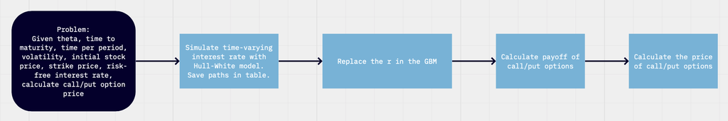

- For more details of the code and instructions, please visit my [Github](https://github.com/isthatlowsonli/Financial_Engineering)
- [Source code](https://github.com/isthatlowsonli/Financial_Engineering/blob/master/Script/HW5.Rmd)
- [Academic Portfolio](https://isthatlowsonli.github.io//Financial_Engineering/Script/practice.nb.html)

# 2 Load packages

```r
library(dplyr)
library(Sim.DiffProc)
```

# 3 Question

HW5 Option Pricing with Hull White Model

1. 透過 Monte Carlo method
   1. 對 Hull White Model 模擬 Short Rate
   2. 將 Short Rate 帶入 Geometric Brownian Motion，r 換成 r(t) 模擬股價
   3. 自訂選擇權履約價，對每一條 path 計算出到期日時的 PayOff
2. 對所有 Path 的 PayOff 進行期望值計算，並折現回 t=0 的時間點
3. 計算出 Call Price & Put Price

# 4 Simulate the Short Rate with Hull White Model

Since I can’t not find the stable function available in R to solve time-dependent theta, I fix theta in the rest of the code. If there’s method to better simulate the one factor Hull-White Model, I will update it.

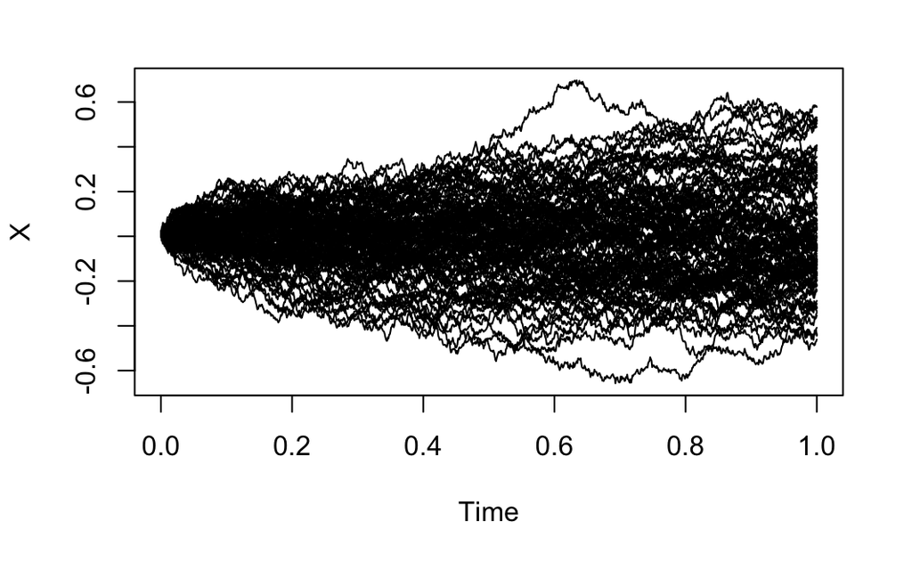

```r
# Hull-White Model
library(Sim.DiffProc)
set.seed(2020)
X <- HWV(
  N = 1000,  # number of simulation steps
  M = 100, # number of trajectories
  mu = 0.01,
  theta = 2.5,
  sigma = 0.3,
  x0 = 0.01
  )
  plot(X, plot.type = "single")
```

# 5 Simulate the stock price with Geometric Brownian Motion

```r
# Hull-White variables
theta <- 2.5
# GBM variables
TM <- 10 # time to maturity, year
N <- 100 # number of Path
dt <- 1 / 12 # time period, count in month
sigma <- 0.1
S0 <- 100 # initial price
# payoff variables
strike_price <- 105
riskfree_rate <- 0.01
# Hull-White model
library(Sim.DiffProc)
set.seed(2020)
r <- Sim.DiffProc::HWV(
  N = round(TM / dt) - 1, # number of simulation steps
  M = N, # number of trajectories
  mu = riskfree_rate,
  theta = theta,
  sigma = sigma,
  x0 = riskfree_rate
)
# Simulation of GBM, with time varying interest rate
S <- list()
payoff_c <- c() # payoff of call option
payoff_p <- c() # payoff of put option
call_price <- c()
put_price <- c()
for (i in 1:N) {
  n <- round(TM / dt) # how many periods
  t_index <- seq(0, TM, length.out = n) # time index
  W <- cumsum(rnorm(n)) * sqrt(dt) # standard brownian motion
  X <-
    (r[,i] - 0.5 * sigma^2) * t_index + sigma * W # r should be vector, varing with periods of time
  S[[i]] <-
    S0 * exp(X) # geomatric brownian motion, save each path in list
  payoff_c[i] <-
    max(0, tail(S[[i]], 1) - strike_price) * exp(-riskfree_rate) # present value of the payoff of call option
  payoff_p[i] <-
    max(0, strike_price - tail(S[[i]], 1)) * exp(-riskfree_rate) # present value of the payoff of put option
  call_price <- mean(payoff_c)
  put_price <- mean(payoff_p)
}
cat(
  "Call option price: ",
  round(call_price, 4),
  "\n",
  "Put option price: ",
  round(put_price, 4)
)
```

```
Call option price:  100.1693
 Put option price:  21.8756
```

# 6 References

[Brownian motion, binomial trees and Monte Carlo simulations](http://computationalfinance.lsi.upc.edu/?page_id=83)

[Calibrated Hull and White short-rates with RQuantLib and ESGtoolkit](https://thierrymoudiki.wordpress.com/2014/12/24/calibrated-hull-and-white-short-rates-with-rquantlib-and-esgtoolkit/)

[GeometricBrownianMotion: Simulate paths from a Arithmetic or Geometric Brownian Motion](https://rdrr.io/rforge/fExpressCertificates/man/GeometricBrownianMotion.html)

[RQuantLib manual](https://cran.r-project.org/web/packages/RQuantLib/RQuantLib.pdf)

[R语言模拟随机微分方程](https://wemp.app/posts/e9fa18e2-cb10-42a0-a7fa-37972d83a701)